# 1 - Introduction

## 1.1 - Business Problem & Interested Stakeholders

Where to open a restaurant in Lisbon?

This is the question that we will help to answer, understanding the actual configuration and possibilities using available data. Lisbon is the capital city of Portugal and one of the most beautuiful and charismatic cities of Europe. It has a vibrant life with lots of people coming from suburbs to work and many tourists. It is also well known by having a great climate and of course the great food. Those who try to open a new restaurant face a great competition and challenge. All the help they can have is for sure wellcome.

This kind of knowledge can have a lot of interested stakeholders:

- Someone who wants to open a new restaurant and know the competition.
- Local authorities who want to better develop their municipalities.
- Real estate agents who want to get additional knowledge for their clients.
- Other intereste stakeholdes like students, foodies or just curious people.

# 2 - Data section

On this section we will gather all the information needed to answer the question of this problem.

Since the new administrative reordering on 2013, Lisbon is divided into 24 borgoughs (freguesias in Portuguese). We will use this administrative division for our sutdy.

For this we need the following data:

- Coordinates to search from using the Foursquare API

  > Using the wikipedia page in which we can get the borough's coordinates: https://pt.wikipedia.org/wiki/Lisboa
- Boroughs shapes to match with the venues location

  > Define in which borough the venue belongs, this information does not come from Foursquare API

  > https://geodados-cml.hub.arcgis.com/datasets/freguesias-2012?geometry=-9.315%2C38.702%2C-8.988%2C38.749&page=2&selectedAttribute=Shape__Length
- Aditional information by borough (population, population density, visiting population)

  > It will be helpful for the final anaysis, use also wikipedia page: https://pt.wikipedia.org/wiki/Lista_de_freguesias_de_Lisboa
- Venues information

  > Use the Foursquare API to get explore the venues location and other relevant information

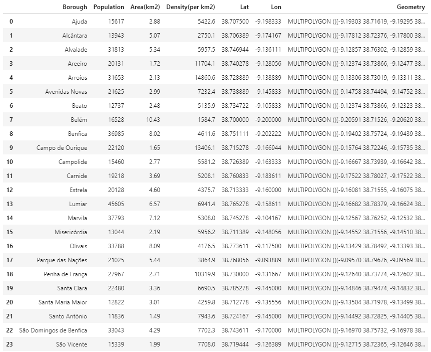